# Clasificarea potabilității apei

- Încărcarea bibliotecilor necesare în proiect:

```r
library(tidyverse)
library(modelr)
library(caret)
library(rsample)
```

```r
library(corrplot)
library(dplyr)
library(magrittr)
library(corrplot)
library(rpart)
library(rpart.plot)
library(ISLR)
library(partykit)
library(tree)
library(ipred)
library(randomForest)
library(ranger)
library(pROC)
library(ggplot2)
library(reshape2)
```

- Încărcarea bazei de date:

```r
water <- read.csv("water_quality.csv")
data(water)
summary(water)
```

```
##    aluminium        ammonia             arsenic           barium
##  Min.   :0.0000   Length:7999        Min.   :0.0000   Min.   :0.000
##  1st Qu.:0.0400   Class :character   1st Qu.:0.0300   1st Qu.:0.560
##  Median :0.0700   Mode  :character   Median :0.0500   Median :1.190
##  Mean   :0.6662                      Mean   :0.1614   Mean   :1.568
##  3rd Qu.:0.2800                      3rd Qu.:0.1000   3rd Qu.:2.480
##  Max.   :5.0500                      Max.   :1.0500   Max.   :4.940
##     cadmium          chloramine       chromium          copper
##  Min.   :0.00000   Min.   :0.000   Min.   :0.0000   Min.   :0.0000
##  1st Qu.:0.00800   1st Qu.:0.100   1st Qu.:0.0500   1st Qu.:0.0900
##  Median :0.04000   Median :0.530   Median :0.0900   Median :0.7500
##  Mean   :0.04281   Mean   :2.177   Mean   :0.2472   Mean   :0.8059
##  3rd Qu.:0.07000   3rd Qu.:4.240   3rd Qu.:0.4400   3rd Qu.:1.3900
##  Max.   :0.13000   Max.   :8.680   Max.   :0.9000   Max.   :2.0000
##     flouride         bacteria         viruses            lead
##  Min.   :0.0000   Min.   :0.0000   Min.   :0.0000   Min.   :0.00000
##  1st Qu.:0.4050   1st Qu.:0.0000   1st Qu.:0.0020   1st Qu.:0.04800
##  Median :0.7700   Median :0.2200   Median :0.0080   Median :0.10200
##  Mean   :0.7716   Mean   :0.3197   Mean   :0.3286   Mean   :0.09945
##  3rd Qu.:1.1600   3rd Qu.:0.6100   3rd Qu.:0.7000   3rd Qu.:0.15100
##  Max.   :1.5000   Max.   :1.0000   Max.   :1.0000   Max.   :0.20000
##     nitrates         nitrites       mercury          perchlorate
##  Min.   : 0.000   Min.   :0.00   Min.   :0.000000   Min.   : 0.00
##  1st Qu.: 5.000   1st Qu.:1.00   1st Qu.:0.003000   1st Qu.: 2.17
##  Median : 9.930   Median :1.42   Median :0.005000   Median : 7.74
##  Mean   : 9.819   Mean   :1.33   Mean   :0.005194   Mean   :16.46
##  3rd Qu.:14.610   3rd Qu.:1.76   3rd Qu.:0.008000   3rd Qu.:29.48
##  Max.   :19.830   Max.   :2.93   Max.   :0.010000   Max.   :60.01
##      radium         selenium           silver          uranium
##  Min.   :0.000   Min.   :0.00000   Min.   :0.0000   Min.   :0.00000
##  1st Qu.:0.820   1st Qu.:0.02000   1st Qu.:0.0400   1st Qu.:0.02000
##  Median :2.410   Median :0.05000   Median :0.0800   Median :0.05000
##  Mean   :2.921   Mean   :0.04968   Mean   :0.1478   Mean   :0.04467
##  3rd Qu.:4.670   3rd Qu.:0.07000   3rd Qu.:0.2400   3rd Qu.:0.07000
##  Max.   :7.990   Max.   :0.10000   Max.   :0.5000   Max.   :0.09000
##    is_safe
##  Length:7999
##  Class :character
##  Mode  :character
##
##
##
```

- Curățarea datelor

Convertim atributul ammonia din caracter in numeric (chr to dbl).

```r
water$ammonia <- as.numeric(water$ammonia)
```

Eliminăm eventualele observații care conțin valori lipsă si redenumim variabila dependenta.

```r
(water <- drop_na(water) %>%
  rename(potability = is_safe))
```

| aluminium | ammonia | arsenic | barium | cadmium | chloramine | chromium | copper | flouride | bacteria | viruses | lead | nitrates | nitrites | mercury | perchlorate | radium | selenium | silver | uranium | potability |
| --- | --- | --- | --- | --- | --- | --- | --- | --- | --- | --- | --- | --- | --- | --- | --- | --- | --- | --- | --- | --- |
| 1.65 | 9.08 | 0.040 | 2.85 | 0.007 | 0.35 | 0.83 | 0.17 | 0.05 | 0.20 | 0.000 | 0.054 | 16.08 | 1.13 | 0.007 | 37.75 | 6.78 | 0.08 | 0.34 | 0.02 | 1 |
| 2.32 | 21.16 | 0.010 | 3.31 | 0.002 | 5.28 | 0.68 | 0.66 | 0.90 | 0.65 | 0.650 | 0.100 | 2.01 | 1.93 | 0.003 | 32.26 | 3.21 | 0.08 | 0.27 | 0.05 | 1 |
| 1.01 | 14.02 | 0.040 | 0.58 | 0.008 | 4.24 | 0.53 | 0.02 | 0.99 | 0.05 | 0.003 | 0.078 | 14.16 | 1.11 | 0.006 | 50.28 | 7.07 | 0.07 | 0.44 | 0.01 | 0 |
| 1.36 | 11.33 | 0.040 | 2.96 | 0.001 | 7.23 | 0.03 | 1.66 | 1.08 | 0.71 | 0.710 | 0.016 | 1.41 | 1.29 | 0.004 | 9.12 | 1.72 | 0.02 | 0.45 | 0.05 | 1 |
| 0.92 | 24.33 | 0.030 | 0.20 | 0.006 | 2.67 | 0.69 | 0.57 | 0.61 | 0.13 | 0.001 | 0.117 | 6.74 | 1.11 | 0.003 | 16.90 | 2.41 | 0.02 | 0.06 | 0.02 | 1 |
| 0.94 | 14.47 | 0.030 | 2.88 | 0.003 | 0.80 | 0.43 | 1.38 | 0.11 | 0.67 | 0.670 | 0.135 | 9.75 | 1.89 | 0.006 | 27.17 | 5.42 | 0.08 | 0.19 | 0.02 | 1 |
| 2.36 | 5.60 | 0.010 | 1.35 | 0.004 | 1.28 | 0.62 | 1.88 | 0.33 | 0.13 | 0.007 | 0.021 | 18.60 | 1.78 | 0.007 | 45.34 | 2.84 | 0.10 | 0.24 | 0.08 | 0 |
| 3.93 | 19.87 | 0.040 | 0.66 | 0.001 | 6.22 | 0.10 | 1.86 | 0.86 | 0.16 | 0.005 | 0.197 | 13.65 | 1.81 | 0.001 | 53.35 | 7.24 | 0.08 | 0.08 | 0.07 | 0 |
| 0.60 | 24.58 | 0.010 | 0.71 | 0.005 | 3.14 | 0.77 | 1.45 | 0.98 | 0.35 | 0.002 | 0.167 | 14.66 | 1.84 | 0.004 | 23.43 | 4.99 | 0.08 | 0.25 | 0.08 | 1 |
| 0.22 | 16.76 | 0.020 | 1.37 | 0.007 | 6.40 | 0.49 | 0.82 | 1.24 | 0.83 | 0.830 | 0.109 | 4.79 | 1.46 | 0.010 | 30.42 | 0.08 | 0.03 | 0.31 | 0.01 | 1 |

[output cut: 7986 more lines]

Transformăm atributul potability in factor:

```r
water <- water %>%
  mutate(potability = ifelse(potability == 0, "No", "Yes"))
water <- water %>% mutate(potability = factor(potability))
table(water$potability)
```

```
##
##   No  Yes
## 7084  912
```

## Vizualizarea datelor

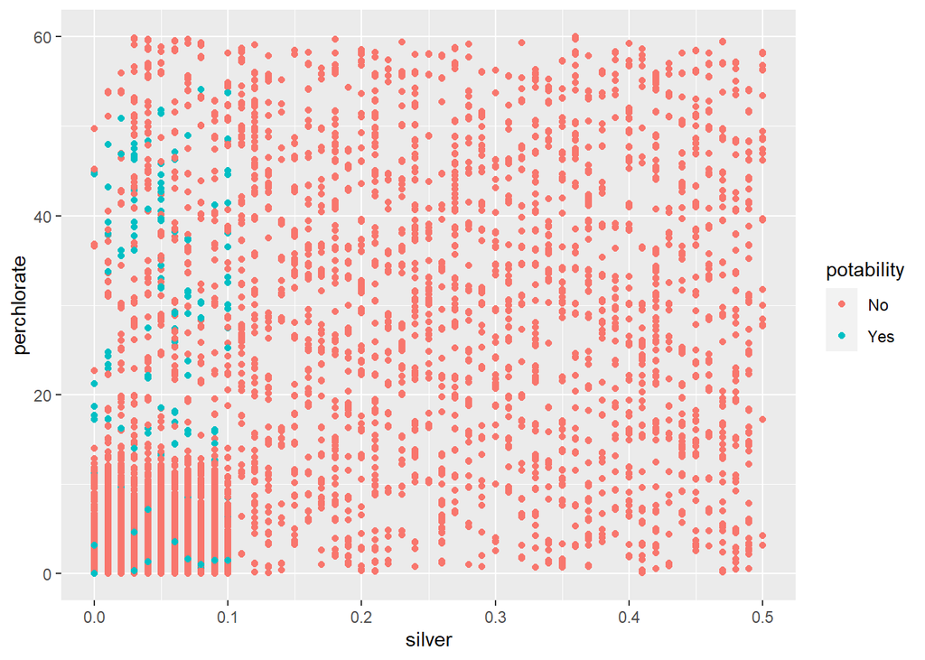

```r
water %>% ggplot(aes(x=silver,y=perchlorate,color=potability))+
  geom_point()
```

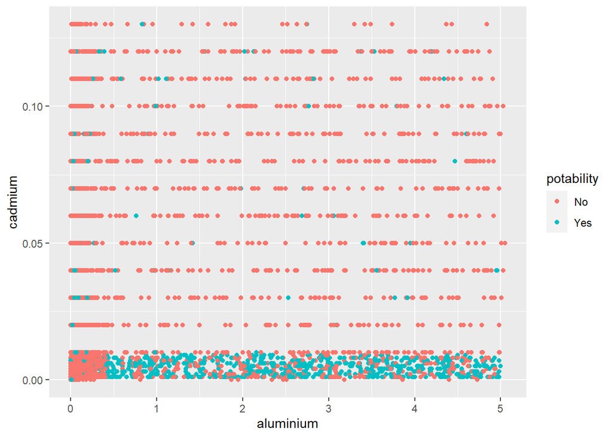

```r
water %>% ggplot(aes(x=aluminium,y=cadmium,color=potability))+
  geom_point()
```

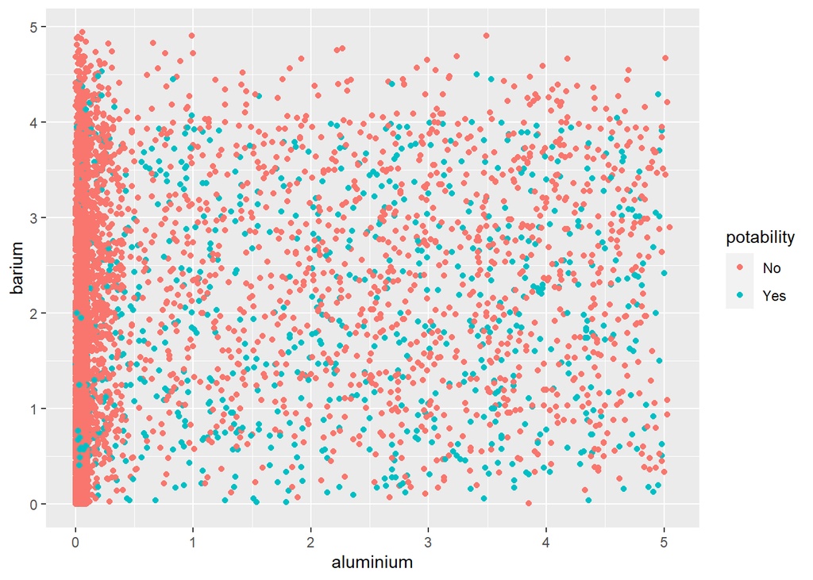

```r
water %>% ggplot(aes(x=aluminium,y=barium,color=potability))+
  geom_point()
```

Grupam datele dupa variabila tinta potabilitate. Observam ca avem mai multe date pentru valoarea No, deci mai multe date pentru apa nepotabila.

```r
by_potability <- group_by(water, potability)
summarize(by_potability, count=n())
```

| potability | count |
| --- | --- |
| No | 7084 |
| Yes | 912 |

- Vizualizarea valorilor medii ale fiecărei variabile, comparativ pentru apa potabilă și nepotabilă:

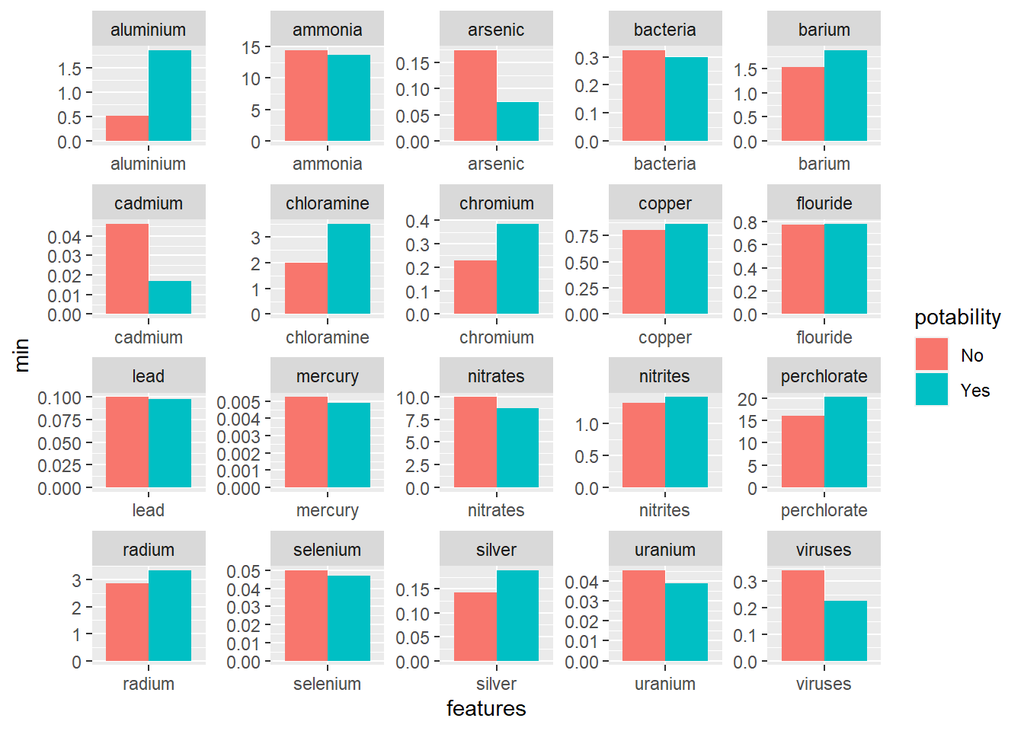

```r
water %>% group_by(potability) %>%
  summarize_all(~mean(.)) %>%
  ungroup() %>%
  #restructuram dataset - in afara de potability, preluam toate col, names_to preia de pe coloane, values_to preia din celule
  pivot_longer(!potability, names_to = "features", values_to = "min") %>%
  #cream graficul pe orizontala prop, pe vert valori min)
  ggplot(aes(features, min, fill = potability)) +
  #design-ul graficului
  geom_bar(stat = "identity", position = "dodge") +
  facet_wrap(~features, scales = "free")
```

- Vizualizarea distribuției valorilor atributelor, pe categorii de potabilitate, sub forma de boxplot:

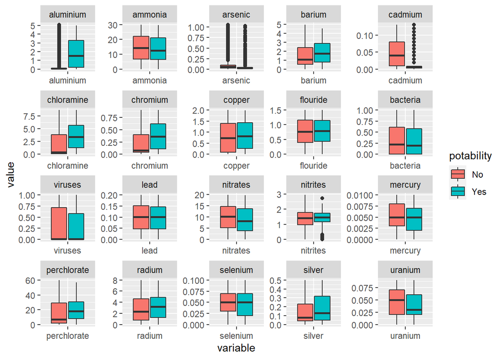

```r
water.m <- melt(water, id.var = "potability")
p <- ggplot(data = water.m, aes(x=variable, y=value)) +
             geom_boxplot(aes(fill=potability))
p + facet_wrap( ~ variable, scale="free")
```

- Distributia valorilor fiecărei variabile pentru apa nepotabilă (digrame de densitate):

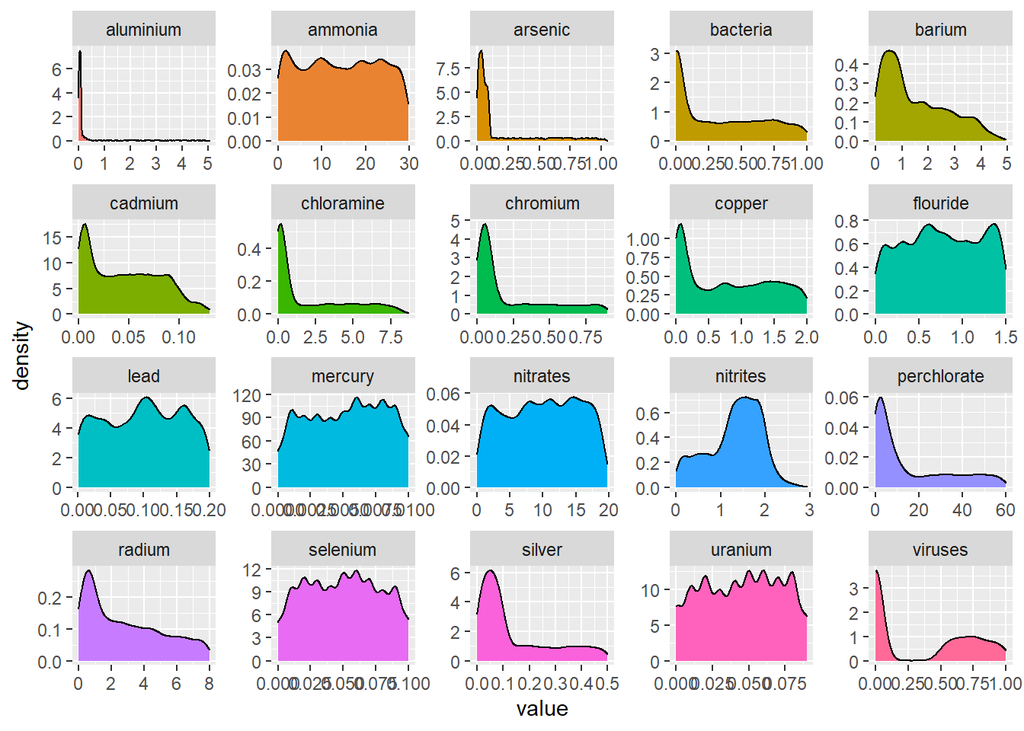

```r
water %>%
  filter(potability == "No") %>%
  select_if(is.numeric) %>%
  gather(metric, value) %>%
  ggplot(aes(value, fill=metric)) +
  geom_density(show.legend = FALSE) +
  facet_wrap(~metric, scales = "free")
```

- Matricea de corelație între proprietățile chimice:

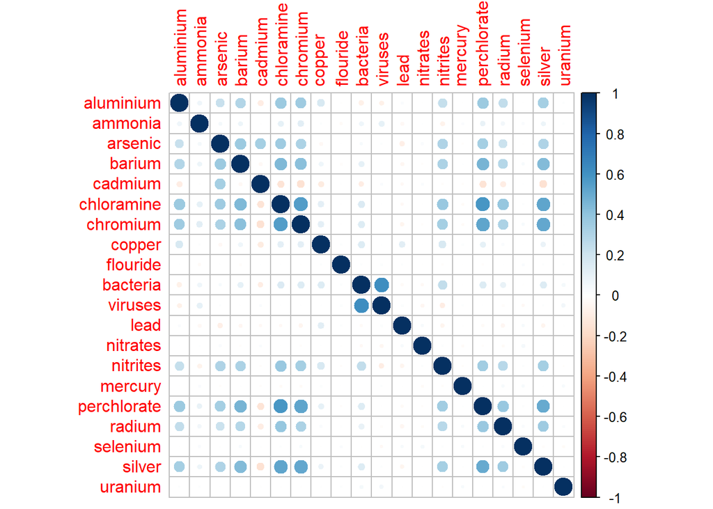

```r
correlations <- cor(water[,1:20])
# create correlation plot
corrplot(correlations, method="circle")
```

## Împărțirea datelor

Împărțim datele în set de antrenare și de test:

```r
set.seed(123)
split <- initial_split(water, prop=0.7, strata= "potability")
train <-training(split)
test <- testing(split)
```

Selectăm în features toate atributele în afară de potability:

```r
features <- setdiff(names(train), "potability")
features
```

```
##  [1] "aluminium"   "ammonia"     "arsenic"     "barium"      "cadmium"
##  [6] "chloramine"  "chromium"    "copper"      "flouride"    "bacteria"
## [11] "viruses"     "lead"        "nitrates"    "nitrites"    "mercury"
## [16] "perchlorate" "radium"      "selenium"    "silver"      "uranium"
```

Separăm variabilele

```r
#x sunt variabilele independente (predictori)
#y este variabila dependenta (potabilitatea)
x <- train[,features]
y <- train$potability
```

10-fold Cross-Validation

```r
train_control <- trainControl(
  method="cv",
  number=10)
```

## Regresie Logistică

Generarea câte unui model in funcție de proprietati:

```r
model_al<-glm(data=water, potability ~ aluminium, family=binomial)
summary(model_al)$coefficients
```

```
##               Estimate Std. Error   z value      Pr(>|z|)
## (Intercept) -2.6616704 0.04895304 -54.37191  0.000000e+00
## aluminium    0.5748442 0.02173923  26.44271 4.425948e-154
```

```r
model_am<-glm(data=water, potability ~ ammonia, family=binomial)
summary(model_am)$coefficients
```

```
##                 Estimate  Std. Error    z value      Pr(>|z|)
## (Intercept) -1.935818672 0.065071960 -29.748891 1.792362e-194
## ammonia     -0.008134556 0.003970972  -2.048505  4.051054e-02
```

```r
model_ar<-glm(data=water, potability ~ arsenic, family=binomial)
summary(model_ar)$coefficients
```

```
##              Estimate Std. Error   z value     Pr(>|z|)
## (Intercept) -1.754370 0.04091601 -42.87735 0.000000e+00
## arsenic     -2.629109 0.26146407 -10.05534 8.702309e-24
```

```r
model_br<-glm(data=water, potability ~ barium, family=binomial)
summary(model_br)$coefficients
```

```
##               Estimate Std. Error    z value     Pr(>|z|)
## (Intercept) -2.4277423 0.06164343 -39.383633 0.000000e+00
## barium       0.2225014 0.02760511   8.060152 7.619939e-16
```

```r
model_cd<-glm(data=water, potability ~ cadmium, family=binomial)
summary(model_cd)$coefficients
```

```
##               Estimate Std. Error   z value      Pr(>|z|)
## (Intercept)  -1.098037 0.04722989 -23.24878 1.463422e-119
## cadmium     -32.606817 1.58926613 -20.51690  1.521015e-93
```

```r
model_cl<-glm(data=water, potability ~ chloramine, family=binomial)
summary(model_cl)$coefficients
```

```
##               Estimate Std. Error   z value     Pr(>|z|)
## (Intercept) -2.6050657 0.05480733 -47.53134 0.000000e+00
## chloramine   0.2038555 0.01264198  16.12528 1.694868e-58
```

```r
model_cr<-glm(data=water, potability ~ chromium, family=binomial)
summary(model_cr)$coefficients
```

```
##              Estimate Std. Error   z value     Pr(>|z|)
## (Intercept) -2.608366 0.05527032 -47.19288 0.000000e+00
## chromium     1.845221 0.11710433  15.75707 6.141454e-56
```

```r
model_cp<-glm(data=water, potability ~ copper, family=binomial)
summary(model_cp)$coefficients
```

```
##               Estimate Std. Error    z value    Pr(>|z|)
## (Intercept) -2.1668364 0.05759953 -37.618997 0.000000000
## copper       0.1409491 0.05347926   2.635584 0.008399267
```

```r
model_fl<-glm(data=water, potability ~ flouride, family=binomial)
summary(model_fl)$coefficients
```

```
##                Estimate Std. Error     z value      Pr(>|z|)
## (Intercept) -2.08665196 0.07210026 -28.9409758 3.645079e-184
## flouride     0.04734553 0.08083399   0.5857131  5.580683e-01
```

```r
model_bc<-glm(data=water, potability ~ bacteria, family=binomial)
summary(model_bc)$coefficients
```

```
##               Estimate Std. Error    z value   Pr(>|z|)
## (Intercept) -1.9833769  0.0480927 -41.240707 0.00000000
## bacteria    -0.2142106  0.1085627  -1.973152 0.04847829
```

```r
model_vs<-glm(data=water, potability ~ viruses, family=binomial)
summary(model_vs)$coefficients
```

```
##               Estimate Std. Error    z value    Pr(>|z|)
## (Intercept) -1.8040649 0.04281405 -42.137215 0.00000e+00
## viruses     -0.8715308 0.10174621  -8.565732 1.07391e-17
```

```r
model_ld<-glm(data=water, potability ~ lead, family=binomial)
summary(model_ld)$coefficients
```

```
##               Estimate Std. Error     z value      Pr(>|z|)
## (Intercept) -1.9967497 0.06891607 -28.9736449 1.413744e-184
## lead        -0.5389035 0.60454187  -0.8914246  3.727014e-01
```

```r
model_na<-glm(data=water, potability ~ nitrates, family=binomial)
summary(model_na)$coefficients
```

```
##                Estimate  Std. Error    z value      Pr(>|z|)
## (Intercept) -1.66583587 0.066823038 -24.929065 3.602336e-137
## nitrates    -0.04115851 0.006413547  -6.417433  1.385912e-10
```

```r
model_ni<-glm(data=water, potability ~ nitrites, family=binomial)
summary(model_ni)$coefficients
```

```
##               Estimate Std. Error    z value      Pr(>|z|)
## (Intercept) -2.4130471 0.09537934 -25.299474 3.237051e-141
## nitrites     0.2663694 0.06350667   4.194354  2.736505e-05
```

```r
model_mc<-glm(data=water, potability ~ mercury, family=binomial)
summary(model_mc)$coefficients
```

```
##               Estimate  Std. Error    z value      Pr(>|z|)
## (Intercept)  -1.852674  0.06821121 -27.160845 1.885354e-162
## mercury     -38.987568 11.85629357  -3.288344  1.007787e-03
```

```r
model_pc<-glm(data=water, potability ~ perchlorate, family=binomial)
summary(model_pc)$coefficients
```

```
##                Estimate  Std. Error    z value     Pr(>|z|)
## (Intercept) -2.27643680 0.050869873 -44.750196 0.000000e+00
## perchlorate  0.01256253 0.001867071   6.728467 1.714594e-11
```

```r
model_rd<-glm(data=water, potability ~ radium, family=binomial)
summary(model_rd)$coefficients
```

```
##                Estimate Std. Error    z value   Pr(>|z|)
## (Intercept) -2.31258410 0.05971941 -38.724160 0.0000e+00
## radium       0.08474178 0.01469619   5.766241 8.1059e-09
```

```r
model_sl<-glm(data=water, potability ~ selenium, family=binomial)
summary(model_sl)$coefficients
```

```
##             Estimate Std. Error    z value      Pr(>|z|)
## (Intercept) -1.88529 0.06807856 -27.692864 8.510037e-169
## selenium    -3.38799 1.22621078  -2.762975  5.727714e-03
```

```r
model_sv<-glm(data=water, potability ~ silver, family=binomial)
summary(model_sv)$coefficients
```

```
##              Estimate Std. Error    z value    Pr(>|z|)
## (Intercept) -2.386728 0.05414947 -44.076659 0.00000e+00
## silver       2.044058 0.22499897   9.084745 1.03942e-19
```

```r
model_ur<-glm(data=water, potability ~ uranium, family=binomial)
summary(model_ur)$coefficients
```

```
##              Estimate Std. Error    z value      Pr(>|z|)
## (Intercept) -1.674031 0.06335263 -26.424024 7.257885e-154
## uranium     -8.909821 1.32436231  -6.727631  1.724476e-11
```

Crearea modelelor pe date specifice 1. Primul model creat pe toate variabilele

```r
model_final <- glm(data=train, potability~aluminium+barium+chloramine+chromium+silver+copper+nitrites+perchlorate+radium+ammonia+arsenic+cadmium+bacteria+viruses+lead+nitrates+mercury+selenium+uranium+flouride, family=binomial)
summary(model_final)$coefficients
```

```
##                 Estimate   Std. Error    z value     Pr(>|z|)
## (Intercept)   0.88139406  0.279479880   3.153694 1.612179e-03
## aluminium     0.69932105  0.038804138  18.021816 1.313592e-72
## barium        0.13562309  0.046982758   2.886657 3.893590e-03
## chloramine    0.17778567  0.024118991   7.371190 1.691116e-13
## chromium      1.41453036  0.216054816   6.547090 5.866895e-11
## silver       -1.72079116  0.411731158  -4.179405 2.922731e-05
## copper       -0.42005624  0.085106341  -4.935663 7.987883e-07
## nitrites     -0.33592392  0.118240163  -2.841031 4.496800e-03
## perchlorate  -0.02493438  0.003645436  -6.839890 7.925385e-12
## radium       -0.06450054  0.023601457  -2.732905 6.277846e-03
## ammonia      -0.02820654  0.005793412  -4.868727 1.123195e-06
## arsenic      -2.74412293  0.349812418  -7.844555 4.344897e-15
## cadmium     -21.77491669  2.115400694 -10.293519 7.537063e-25
## bacteria      0.77927948  0.254644455   3.060265 2.211413e-03
## viruses      -1.30306648  0.218077974  -5.975232 2.297630e-09
## lead         -1.68644056  0.884950440  -1.905689 5.669053e-02
## nitrates     -0.04950261  0.009173743  -5.396119 6.809772e-08
## mercury     -36.97273399 16.520455938  -2.237997 2.522124e-02
## selenium     -4.87930948  1.752597354  -2.784045 5.368563e-03
## uranium     -15.73811760  1.926195235  -8.170572 3.069297e-16
## flouride      0.20682110  0.115720130   1.787253 7.389668e-02
```

Observam faptul ca proprietatea aluminium este cea mai seminificativa, deoarece inregistreaza cea mai mica valoare a lui p.

Realizăm matricea de confuzie, considerând valoarea de 0.3 drept prag pentru clasificarea in Yes/No:

```r
pred_mx <- predict(model_final, newdata=test)
(conf1 <- confusionMatrix(factor(ifelse(pred_mx>0.3, "Yes", "No")), factor(test$potability)))
```

```
## Confusion Matrix and Statistics
##
##           Reference
## Prediction   No  Yes
##        No  2096  191
##        Yes   30   83
##
##                Accuracy : 0.9079
##                  95% CI : (0.8956, 0.9192)
##     No Information Rate : 0.8858
##     P-Value [Acc > NIR] : 0.0002664
##
##                   Kappa : 0.3881
##
##  Mcnemar's Test P-Value : < 2.2e-16
##
##             Sensitivity : 0.9859
##             Specificity : 0.3029
##          Pos Pred Value : 0.9165
##          Neg Pred Value : 0.7345
##              Prevalence : 0.8858
##          Detection Rate : 0.8733
##    Detection Prevalence : 0.9529
##       Balanced Accuracy : 0.6444
##
##        'Positive' Class : No
##
```

2. Modelul 2 s-a realizat pe variabilele independente cu o relatie directa determinantă cu variabila dependenta:

```r
model_2 <- glm(data=train, potability~aluminium+barium+chloramine+chromium+copper, family=binomial)
summary(model_2)
```

```
##
## Call:
## glm(formula = potability ~ aluminium + barium + chloramine +
##     chromium + copper, family = binomial, data = train)
##
## Deviance Residuals:
##     Min       1Q   Median       3Q      Max
## -1.5092  -0.4474  -0.3502  -0.3099   2.5019
##
## Coefficients:
##             Estimate Std. Error z value Pr(>|z|)
## (Intercept) -2.75099    0.10087 -27.272  < 2e-16 ***
## aluminium    0.49500    0.02940  16.837  < 2e-16 ***
## barium      -0.09843    0.03963  -2.484   0.0130 *
## chloramine   0.09263    0.01935   4.787 1.70e-06 ***
## chromium     0.85293    0.17667   4.828 1.38e-06 ***
## copper      -0.20793    0.07283  -2.855   0.0043 **
## ---
## Signif. codes:  0 '***' 0.001 '**' 0.01 '*' 0.05 '.' 0.1 ' ' 1
##
## (Dispersion parameter for binomial family taken to be 1)
##
##     Null deviance: 3971.1  on 5595  degrees of freedom
## Residual deviance: 3464.8  on 5590  degrees of freedom
## AIC: 3476.8
##
## Number of Fisher Scoring iterations: 5
```

```r
pred_test_2 <- predict(model_2, newdata=test, type="response")
(conf2 <- confusionMatrix(factor(ifelse(pred_test_2>0.3, "Yes", "No")), factor(test$potability)))
```

```
## Confusion Matrix and Statistics
##
##           Reference
## Prediction   No  Yes
##        No  1991  198
##        Yes  135   76
##
##                Accuracy : 0.8612
##                  95% CI : (0.8468, 0.8748)
##     No Information Rate : 0.8858
##     P-Value [Acc > NIR] : 0.9998991
##
##                   Kappa : 0.2377
##
##  Mcnemar's Test P-Value : 0.0006798
##
##             Sensitivity : 0.9365
##             Specificity : 0.2774
##          Pos Pred Value : 0.9095
##          Neg Pred Value : 0.3602
##              Prevalence : 0.8858
##          Detection Rate : 0.8296
##    Detection Prevalence : 0.9121
##       Balanced Accuracy : 0.6069
##
##        'Positive' Class : No
##
```

3. Modelul 3 s-a realizat pe variabilele independente cu o relatie indirecta cu variabila dependenta:

```r
model_3 <- glm(data=train, potability~arsenic+cadmium+mercury+selenium+uranium, family=binomial)
summary(model_3)
```

```
##
## Call:
## glm(formula = potability ~ arsenic + cadmium + mercury + selenium +
##     uranium, family = binomial, data = train)
##
## Deviance Residuals:
##     Min       1Q   Median       3Q      Max
## -1.0411  -0.5754  -0.3347  -0.1912   3.4096
##
## Coefficients:
##             Estimate Std. Error z value Pr(>|z|)
## (Intercept)  -0.1449     0.1348  -1.075 0.282562
## arsenic      -0.9468     0.2683  -3.528 0.000418 ***
## cadmium     -30.0864     1.9047 -15.796  < 2e-16 ***
## mercury     -47.3750    14.7246  -3.217 0.001294 **
## selenium     -3.6137     1.5336  -2.356 0.018454 *
## uranium     -11.4874     1.6565  -6.935 4.07e-12 ***
## ---
## Signif. codes:  0 '***' 0.001 '**' 0.01 '*' 0.05 '.' 0.1 ' ' 1
##
## (Dispersion parameter for binomial family taken to be 1)
##
##     Null deviance: 3971.1  on 5595  degrees of freedom
## Residual deviance: 3453.2  on 5590  degrees of freedom
## AIC: 3465.2
##
## Number of Fisher Scoring iterations: 6
```

```r
pred_test_3 <- predict(model_3, newdata=test, type="response")
(conf3 <- confusionMatrix(factor(ifelse(pred_test_3>0.3, "Yes", "No")), factor(test$potability)))
```

```
## Confusion Matrix and Statistics
##
##           Reference
## Prediction   No  Yes
##        No  2058  231
##        Yes   68   43
##
##                Accuracy : 0.8754
##                  95% CI : (0.8615, 0.8884)
##     No Information Rate : 0.8858
##     P-Value [Acc > NIR] : 0.9478
##
##                   Kappa : 0.1686
##
##  Mcnemar's Test P-Value : <2e-16
##
##             Sensitivity : 0.9680
##             Specificity : 0.1569
##          Pos Pred Value : 0.8991
##          Neg Pred Value : 0.3874
##              Prevalence : 0.8858
##          Detection Rate : 0.8575
##    Detection Prevalence : 0.9537
##       Balanced Accuracy : 0.5625
##
##        'Positive' Class : No
##
```

4. Model folosind Cross-Validation:

```r
model_cv_lr  <- train (
  x=x,
  y=y,
  method="glm",
  family="binomial",
  trControl = train_control
)
model_cv_lr
```

```
## Generalized Linear Model
##
## 5596 samples
##   20 predictor
##    2 classes: 'No', 'Yes'
##
## No pre-processing
## Resampling: Cross-Validated (10 fold)
## Summary of sample sizes: 5036, 5036, 5036, 5037, 5036, 5036, ...
## Resampling results:
##
##   Accuracy   Kappa
##   0.9052935  0.3877808
```

```r
pred_cv_lr = predict (model_cv_lr, newdata=test, type="raw")
(conf4 <- confusionMatrix(pred_cv_lr, test$potability))
```

```
## Confusion Matrix and Statistics
##
##           Reference
## Prediction   No  Yes
##        No  2080  176
##        Yes   46   98
##
##                Accuracy : 0.9075
##                  95% CI : (0.8952, 0.9188)
##     No Information Rate : 0.8858
##     P-Value [Acc > NIR] : 0.0003425
##
##                   Kappa : 0.4236
##
##  Mcnemar's Test P-Value : < 2.2e-16
##
##             Sensitivity : 0.9784
##             Specificity : 0.3577
##          Pos Pred Value : 0.9220
##          Neg Pred Value : 0.6806
##              Prevalence : 0.8858
##          Detection Rate : 0.8667
##    Detection Prevalence : 0.9400
##       Balanced Accuracy : 0.6680
##
##        'Positive' Class : No
##
```

Tabel comparativ:

```r
model <- c('model_final','model_2','model_3', 'model_cv_lr')
accuracy <- c(conf1$overall['Accuracy'], conf2$overall['Accuracy'], conf3$overall['Accuracy'], conf4$overall['Accuracy'])
sensitivity <- c(conf1$byClass['Sensitivity'], conf2$byClass['Sensitivity'], conf3$byClass['Sensitivity'], conf4$byClass['Sensitivity'])
specificity <- c(conf1$byClass['Specificity'], conf2$byClass['Specificity'], conf3$byClass['Specificity'], conf4$byClass['Specificity'])
performance <- data.frame(model, accuracy, sensitivity, specificity)
performance
```

| model | accuracy | sensitivity | specificity |
| --- | --- | --- | --- |
| model_final | 0.9079167 | 0.9858890 | 0.3029197 |
| model_2 | 0.8612500 | 0.9365005 | 0.2773723 |
| model_3 | 0.8754167 | 0.9680151 | 0.1569343 |
| model_cv_lr | 0.9075000 | 0.9783631 | 0.3576642 |

In urma rezultatelor obtinute, alegem ca model reprezentativ modelul obtinut prin cross-validation (model_cv_lr), deoarece prezinta o acuratete ridicata, cât și o rată a specificității ridicată. Deși acuratețea primului model este mai ridicată, procentul nu e semnificativ, specificitatea e redusa, de aceea am ales ultimul model in detrimentului primului.

```r
best_lr <- model_cv_lr
```

## Naive Bayes

1. Primul model, realizat cu Cross-Validation:

```r
mod_nb1 <- train(
  x = x,
  y = y,
  method = "nb",
  trControl = train_control )
mod_nb1
```

```
## Naive Bayes
##
## 5596 samples
##   20 predictor
##    2 classes: 'No', 'Yes'
##
## No pre-processing
## Resampling: Cross-Validated (10 fold)
## Summary of sample sizes: 5036, 5036, 5036, 5037, 5036, 5038, ...
## Resampling results across tuning parameters:
##
##   usekernel  Accuracy   Kappa
##   FALSE      0.8491879  0.3853301
##    TRUE      0.8558024  0.4454213
##
## Tuning parameter 'fL' was held constant at a value of 0
## Tuning
##  parameter 'adjust' was held constant at a value of 1
## Accuracy was used to select the optimal model using the largest value.
## The final values used for the model were fL = 0, usekernel = TRUE and adjust
##  = 1.
```

```r
confusionMatrix(mod_nb1)
```

```
## Cross-Validated (10 fold) Confusion Matrix
##
## (entries are percentual average cell counts across resamples)
##
##           Reference
## Prediction   No  Yes
##        No  77.7  3.5
##        Yes 10.9  7.9
##
##  Accuracy (average) : 0.8558
```

Search grid pentru a identifica parametrii optimi:

```r
search_grid <- expand.grid(
  usekernel = c(TRUE, FALSE),
  fL = 0.5, #la variabilele nominale sa nu porneasca de la 0
  adjust = seq(0, 5, by = 1) ) #ajusteaza kernelii cu (1,2,3,4,5)
```

2. Model cu optimizarea parametrilor:

```r
mod_nb2 = train(
  x = x,
  y = y,
  method = "nb",
  trControl = train_control,
  tuneGrid = search_grid
)

mod_nb2
```

```
## Naive Bayes
##
## 5596 samples
##   20 predictor
##    2 classes: 'No', 'Yes'
##
## No pre-processing
## Resampling: Cross-Validated (10 fold)
## Summary of sample sizes: 5036, 5036, 5036, 5037, 5037, 5036, ...
## Resampling results across tuning parameters:
##
##   usekernel  adjust  Accuracy   Kappa
##   FALSE      0       0.8491736  0.3841657
##   FALSE      1       0.8491736  0.3841657
##   FALSE      2       0.8491736  0.3841657
##   FALSE      3       0.8491736  0.3841657
##   FALSE      4       0.8491736  0.3841657
##   FALSE      5       0.8491736  0.3841657
##    TRUE      0             NaN        NaN
##    TRUE      1       0.8575703  0.4450647
##    TRUE      2       0.8858047  0.5079843
##    TRUE      3       0.9011746  0.5405087
##    TRUE      4       0.9081450  0.5512198
##    TRUE      5       0.9072547  0.5167484
##
## Tuning parameter 'fL' was held constant at a value of 0.5
## Accuracy was used to select the optimal model using the largest value.
## The final values used for the model were fL = 0.5, usekernel = TRUE and
##  adjust = 4.
```

```r
confusionMatrix(mod_nb2)
```

```
## Cross-Validated (10 fold) Confusion Matrix
##
## (entries are percentual average cell counts across resamples)
##
##           Reference
## Prediction   No  Yes
##        No  83.8  4.4
##        Yes  4.8  7.0
##
##  Accuracy (average) : 0.9081
```

```r
best_nb <- mod_nb2$finalModel
```

```r
#predictie pe setul de test, cu probabilitatea aferenta
pred_nb <- predict(best_nb, test, type="prob")
#compara predictiile cu valorile reale
confusionMatrix(pred_nb$class, test$potability)
```

```
## Confusion Matrix and Statistics
##
##           Reference
## Prediction   No  Yes
##        No  1995   97
##        Yes  131  177
##
##                Accuracy : 0.905
##                  95% CI : (0.8926, 0.9164)
##     No Information Rate : 0.8858
##     P-Value [Acc > NIR] : 0.001404
##
##                   Kappa : 0.5544
##
##  Mcnemar's Test P-Value : 0.028854
##
##             Sensitivity : 0.9384
##             Specificity : 0.6460
##          Pos Pred Value : 0.9536
##          Neg Pred Value : 0.5747
##              Prevalence : 0.8858
##          Detection Rate : 0.8313
##    Detection Prevalence : 0.8717
##       Balanced Accuracy : 0.7922
##
##        'Positive' Class : No
##
```

```r
#95% CI = confidence intervals
#no information rate (NIR) e sansa de a face clasificarea random, fara un model
```

## Arbori de decizie

1. Arbore simplu folosind pachetul rpart:

```r
set.seed(123)
mod_tree1 = rpart(
  formula = potability ~. ,
  data = train,
  method = "class"
)
mod_tree1
```

```
## n= 5596
##
## node), split, n, loss, yval, (yprob)
##       * denotes terminal node
##
##   1) root 5596 638 No (0.88598999 0.11401001)
##     2) aluminium< 0.385 4302 200 No (0.95351000 0.04649000)
##       4) aluminium< 0.115 3874 142 No (0.96334538 0.03665462) *
##       5) aluminium>=0.115 428  58 No (0.86448598 0.13551402)
##        10) silver>=0.075 348  25 No (0.92816092 0.07183908) *
##        11) silver< 0.075 80  33 No (0.58750000 0.41250000)
##          22) uranium>=0.035 41   2 No (0.95121951 0.04878049) *
##          23) uranium< 0.035 39   8 Yes (0.20512821 0.79487179) *
##     3) aluminium>=0.385 1294 438 No (0.66151468 0.33848532)
##       6) cadmium>=0.0095 661  31 No (0.95310136 0.04689864) *
##       7) cadmium< 0.0095 633 226 Yes (0.35703002 0.64296998)
##        14) perchlorate>=35.06 247  63 No (0.74493927 0.25506073)
##          28) ammonia>=10.855 170  11 No (0.93529412 0.06470588) *
##          29) ammonia< 10.855 77  25 Yes (0.32467532 0.67532468)
##            58) nitrates>=10.2 35  13 No (0.62857143 0.37142857)
##             116) perchlorate>=42.125 24   3 No (0.87500000 0.12500000) *
##             117) perchlorate< 42.125 11   1 Yes (0.09090909 0.90909091) *
##            59) nitrates< 10.2 42   3 Yes (0.07142857 0.92857143) *
##        15) perchlorate< 35.06 386  42 Yes (0.10880829 0.89119171)
##          30) perchlorate>=25.585 117  30 Yes (0.25641026 0.74358974)
##            60) ammonia>=22.455 29   8 No (0.72413793 0.27586207) *
##            61) ammonia< 22.455 88   9 Yes (0.10227273 0.89772727) *
##          31) perchlorate< 25.585 269  12 Yes (0.04460967 0.95539033) *
```

```r
#nr instante, loss = nr erori (clasificate gresit pe clasa majoritara), clasa majoritara, probabilitatile predictiei
```

```r
summary(mod_tree1)
```

```
## Call:
## rpart(formula = potability ~ ., data = train, method = "class")
##   n= 5596
##
##           CP nsplit rel error    xerror       xstd
## 1 0.14184953      0 1.0000000 1.0000000 0.03726525
## 2 0.04231975      3 0.5266458 0.5266458 0.02785499
## 3 0.01410658      4 0.4843260 0.4890282 0.02690290
## 4 0.01201672      6 0.4561129 0.4435737 0.02569234
## 5 0.01018809      9 0.4200627 0.4216301 0.02508176
## 6 0.01000000     11 0.3996865 0.3996865 0.02445242
##
## Variable importance
##     cadmium     arsenic   aluminium perchlorate    bacteria     ammonia
##          21          20          16          13           7           5
##    nitrites      barium     viruses     uranium    nitrates      silver
##           5           4           3           2           2           2
##  chloramine
##           1
##
## Node number 1: 5596 observations,    complexity param=0.1418495
##   predicted class=No   expected loss=0.11401  P(node) =1
##     class counts:  4958   638
##    probabilities: 0.886 0.114
##   left son=2 (4302 obs) right son=3 (1294 obs)
##   Primary splits:
##       aluminium  < 0.385  to the left,  improve=169.63240, (0 missing)
##       cadmium    < 0.0095 to the right, improve=168.24270, (0 missing)
##       chloramine < 0.645  to the left,  improve= 65.14230, (0 missing)
##       chromium   < 0.105  to the left,  improve= 57.78397, (0 missing)
##       arsenic    < 0.045  to the right, improve= 54.45890, (0 missing)
##   Surrogate splits:
##       chloramine < 7.735  to the left,  agree=0.770, adj=0.005, (0 split)
##       arsenic    < 0.985  to the left,  agree=0.769, adj=0.002, (0 split)
##       ammonia    < -0.005 to the right, agree=0.769, adj=0.002, (0 split)
##       barium     < 4.895  to the left,  agree=0.769, adj=0.002, (0 split)
##       nitrates   < 19.49  to the left,  agree=0.769, adj=0.001, (0 split)
##
## Node number 2: 4302 observations,    complexity param=0.01201672
##   predicted class=No   expected loss=0.04649  P(node) =0.7687634
```

[output cut: 218 more lines]

```
##
## Node number 61: 88 observations
##   predicted class=Yes  expected loss=0.1022727  P(node) =0.01572552
##     class counts:     9    79
##    probabilities: 0.102 0.898
##
## Node number 116: 24 observations
##   predicted class=No   expected loss=0.125  P(node) =0.004288778
##     class counts:    21     3
##    probabilities: 0.875 0.125
##
## Node number 117: 11 observations
##   predicted class=Yes  expected loss=0.09090909  P(node) =0.00196569
##     class counts:     1    10
##    probabilities: 0.091 0.909
```

```r
#CP = cost complexity parameters
#penalizeaza arborele pe baza nr de frunze
```

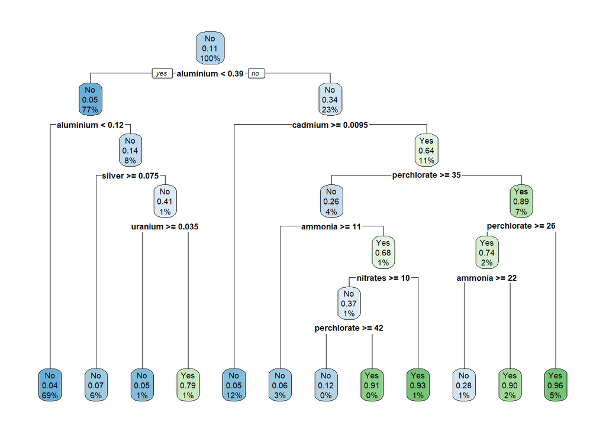

```r
rpart.plot(mod_tree1)
```

```r
#predictie pe test
pred_mod_tree1 <- predict(mod_tree1, newdata = test, target ="class")
#adaugam coloana cu no/yes
pred_mod_tree1 <- as_tibble(pred_mod_tree1) %>% mutate(class = ifelse(No >= Yes, "No", "Yes"))
(cmt1 <- confusionMatrix(factor(pred_mod_tree1$class), factor(test$potability)))
```

```
## Confusion Matrix and Statistics
##
##           Reference
## Prediction   No  Yes
##        No  2096   93
##        Yes   30  181
##
##                Accuracy : 0.9488
##                  95% CI : (0.9392, 0.9572)
##     No Information Rate : 0.8858
##     P-Value [Acc > NIR] : < 2.2e-16
##
##                   Kappa : 0.7184
##
##  Mcnemar's Test P-Value : 2.266e-08
##
##             Sensitivity : 0.9859
##             Specificity : 0.6606
##          Pos Pred Value : 0.9575
##          Neg Pred Value : 0.8578
##              Prevalence : 0.8858
##          Detection Rate : 0.8733
##    Detection Prevalence : 0.9121
##       Balanced Accuracy : 0.8232
##
##        'Positive' Class : No
##
```

Comparatie cu un arbore simplu realizat cu Cross-Validation:

```r
mod_tree_cv <- train(x,y,
                     method = "rpart",
                      trControl = train_control)
pred_mod_tree_cv <- predict(mod_tree_cv, newdata = test, target ="class")
(cmt_cv <- confusionMatrix(pred_mod_tree_cv, factor(test$potability)))
```

```
## Confusion Matrix and Statistics
##
##           Reference
## Prediction   No  Yes
##        No  2078   90
##        Yes   48  184
##
##                Accuracy : 0.9425
##                  95% CI : (0.9324, 0.9515)
##     No Information Rate : 0.8858
##     P-Value [Acc > NIR] : < 2.2e-16
##
##                   Kappa : 0.6954
##
##  Mcnemar's Test P-Value : 0.0004827
##
##             Sensitivity : 0.9774
##             Specificity : 0.6715
##          Pos Pred Value : 0.9585
##          Neg Pred Value : 0.7931
##              Prevalence : 0.8858
##          Detection Rate : 0.8658
##    Detection Prevalence : 0.9033
##       Balanced Accuracy : 0.8245
##
##        'Positive' Class : No
##
```

Modelul realizat prin rpart este cu putin mai bun.

2. Arbore netaiat

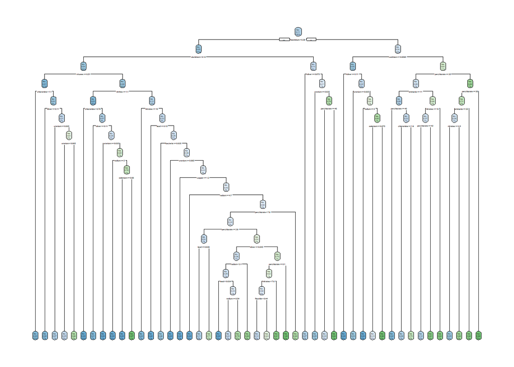

```r
mod_tree_full <- rpart(potability ~.,
            data = train,
            method = "class",
            control = list(cp=0))
rpart.plot(mod_tree_full)
```

Acuratete mai buna pentru arborele netaiat:

```r
pred_tree_full <- predict(mod_tree_full, newdata = test, target = "class")
pred_tree_full <- as_tibble(pred_tree_full) %>% mutate(class = ifelse(No >= Yes, "No", "Yes"))
(cmt2 <- confusionMatrix(factor(pred_tree_full$class), factor(test$potability)))
```

```
## Confusion Matrix and Statistics
##
##           Reference
## Prediction   No  Yes
##        No  2080   48
##        Yes   46  226
##
##                Accuracy : 0.9608
##                  95% CI : (0.9523, 0.9682)
##     No Information Rate : 0.8858
##     P-Value [Acc > NIR] : <2e-16
##
##                   Kappa : 0.8057
##
##  Mcnemar's Test P-Value : 0.9179
##
##             Sensitivity : 0.9784
##             Specificity : 0.8248
##          Pos Pred Value : 0.9774
##          Neg Pred Value : 0.8309
##              Prevalence : 0.8858
##          Detection Rate : 0.8667
##    Detection Prevalence : 0.8867
##       Balanced Accuracy : 0.9016
##
##        'Positive' Class : No
##
```

3. Pruning:

```r
m2_pruned <- prune(mod_tree_full, cp = 0.005)
pred_m2_pruned <- predict(m2_pruned, newdata = test, target = "class")
pred_m2_pruned <- as_tibble(pred_m2_pruned) %>% mutate(class = ifelse(No >= Yes, "No", "Yes"))
(cmt3 <- confusionMatrix(factor(pred_m2_pruned$class), factor(test$potability)))
```

```
## Confusion Matrix and Statistics
##
##           Reference
## Prediction   No  Yes
##        No  2095   79
##        Yes   31  195
##
##                Accuracy : 0.9542
##                  95% CI : (0.945, 0.9622)
##     No Information Rate : 0.8858
##     P-Value [Acc > NIR] : < 2.2e-16
##
##                   Kappa : 0.7547
##
##  Mcnemar's Test P-Value : 7.42e-06
##
##             Sensitivity : 0.9854
##             Specificity : 0.7117
##          Pos Pred Value : 0.9637
##          Neg Pred Value : 0.8628
##              Prevalence : 0.8858
##          Detection Rate : 0.8729
##    Detection Prevalence : 0.9058
##       Balanced Accuracy : 0.8485
##
##        'Positive' Class : No
##
```

4. Cu optimizarea entropiei, folosind functia tree():

```r
set.seed(123)
mod_tree_entropy <- tree(potability ~., data = train)
summary(mod_tree_entropy)
```

```
##
## Classification tree:
## tree(formula = potability ~ ., data = train)
## Variables actually used in tree construction:
##  [1] "cadmium"     "aluminium"   "uranium"     "silver"      "perchlorate"
##  [6] "ammonia"     "chloramine"  "nitrites"    "viruses"     "nitrates"
## [11] "lead"        "radium"      "selenium"
## Number of terminal nodes:  18
## Residual mean deviance:  0.2194 = 1224 / 5578
## Misclassification error rate: 0.03878 = 217 / 5596
```

```r
pred_tree_entropy <- predict(mod_tree_entropy, newdata = test, target = "class")
pred_tree_entropy <- as_tibble(pred_tree_entropy) %>% mutate(class = ifelse(No >= Yes, "No", "Yes"))
(cmt4 <- confusionMatrix(factor(pred_tree_entropy$class), factor(test$potability)))
```

```
## Confusion Matrix and Statistics
##
##           Reference
## Prediction   No  Yes
##        No  2065   53
##        Yes   61  221
##
##                Accuracy : 0.9525
##                  95% CI : (0.9432, 0.9607)
##     No Information Rate : 0.8858
##     P-Value [Acc > NIR] : <2e-16
##
##                   Kappa : 0.7681
##
##  Mcnemar's Test P-Value : 0.5121
##
##             Sensitivity : 0.9713
##             Specificity : 0.8066
##          Pos Pred Value : 0.9750
##          Neg Pred Value : 0.7837
##              Prevalence : 0.8858
##          Detection Rate : 0.8604
##    Detection Prevalence : 0.8825
##       Balanced Accuracy : 0.8889
##
##        'Positive' Class : No
##
```

5. Cu optimizarea coeficientului Gini

```r
set.seed(123)
mod_tree_gini <- tree(potability ~., data = train, split="gini")
summary(mod_tree_gini)
```

```
##
## Classification tree:
## tree(formula = potability ~ ., data = train, split = "gini")
## Number of terminal nodes:  129
## Residual mean deviance:  0.09937 = 543.2 / 5467
## Misclassification error rate: 0.02716 = 152 / 5596
```

```r
pred_tree_gini <- predict(mod_tree_gini, newdata = test, target = "class")
pred_tree_gini <- as_tibble(pred_tree_gini) %>% mutate(class = ifelse(No >= Yes, "No", "Yes"))
(cmt5 <- confusionMatrix(factor(pred_tree_gini$class), factor(test$potability)))
```

```
## Confusion Matrix and Statistics
##
##           Reference
## Prediction   No  Yes
##        No  2083   66
##        Yes   43  208
##
##                Accuracy : 0.9546
##                  95% CI : (0.9455, 0.9626)
##     No Information Rate : 0.8858
##     P-Value [Acc > NIR] : <2e-16
##
##                   Kappa : 0.7669
##
##  Mcnemar's Test P-Value : 0.0351
##
##             Sensitivity : 0.9798
##             Specificity : 0.7591
##          Pos Pred Value : 0.9693
##          Neg Pred Value : 0.8287
##              Prevalence : 0.8858
##          Detection Rate : 0.8679
##    Detection Prevalence : 0.8954
##       Balanced Accuracy : 0.8694
##
##        'Positive' Class : No
##
```

Evaluarea performantei arborilor de decizie:

```r
model <- c('tree1','tree_full','tree_pruned','tree_entropy','tree_gini')
accuracy <- c(cmt1$overall['Accuracy'], cmt2$overall['Accuracy'], cmt3$overall['Accuracy'],cmt4$overall['Accuracy'],cmt5$overall['Accuracy'])
sensitivity <- c(cmt1$byClass['Sensitivity'], cmt2$byClass['Sensitivity'], cmt3$byClass['Sensitivity'],cmt4$byClass['Sensitivity'],cmt5$byClass['Sensitivity'])
specificity <- c(cmt1$byClass['Specificity'], cmt2$byClass['Specificity'], cmt3$byClass['Specificity'],cmt4$byClass['Specificity'],cmt4$byClass['Specificity'])
performance <- data.frame(model, accuracy, sensitivity, specificity)
performance
```

| model | accuracy | sensitivity | specificity |
| --- | --- | --- | --- |
| tree1 | 0.9487500 | 0.9858890 | 0.6605839 |
| tree_full | 0.9608333 | 0.9783631 | 0.8248175 |
| tree_pruned | 0.9541667 | 0.9854186 | 0.7116788 |
| tree_entropy | 0.9525000 | 0.9713076 | 0.8065693 |
| tree_gini | 0.9545833 | 0.9797742 | 0.8065693 |

În acest caz, desi arborele netaiat pare cel mai perfomant, vom face exceptia de alege următorul model ca performanță (tree_gini), pentru a evita overfitting-ul.

```r
best_tree <- mod_tree_gini
```

## Bagging

1. Model simplu:

```r
set.seed(123)
mod_bagged1 <- bagging(potability ~ .,
                     data = train, coob = TRUE)
mod_bagged1
```

```
##
## Bagging classification trees with 25 bootstrap replications
##
## Call: bagging.data.frame(formula = potability ~ ., data = train, coob = TRUE)
##
## Out-of-bag estimate of misclassification error:  0.0397
```

```r
pred_mod_bagged1 <- predict(mod_bagged1, newdata = test, target = "class")
(cmb1 <- confusionMatrix(pred_mod_bagged1, factor(test$potability)))
```

```
## Confusion Matrix and Statistics
##
##           Reference
## Prediction   No  Yes
##        No  2101   69
##        Yes   25  205
##
##                Accuracy : 0.9608
##                  95% CI : (0.9523, 0.9682)
##     No Information Rate : 0.8858
##     P-Value [Acc > NIR] : < 2.2e-16
##
##                   Kappa : 0.7918
##
##  Mcnemar's Test P-Value : 9.202e-06
##
##             Sensitivity : 0.9882
##             Specificity : 0.7482
##          Pos Pred Value : 0.9682
##          Neg Pred Value : 0.8913
##              Prevalence : 0.8858
##          Detection Rate : 0.8754
##    Detection Prevalence : 0.9042
##       Balanced Accuracy : 0.8682
##
##        'Positive' Class : No
##
```

Grafic pentru stabilizarea erorii de clasificare:

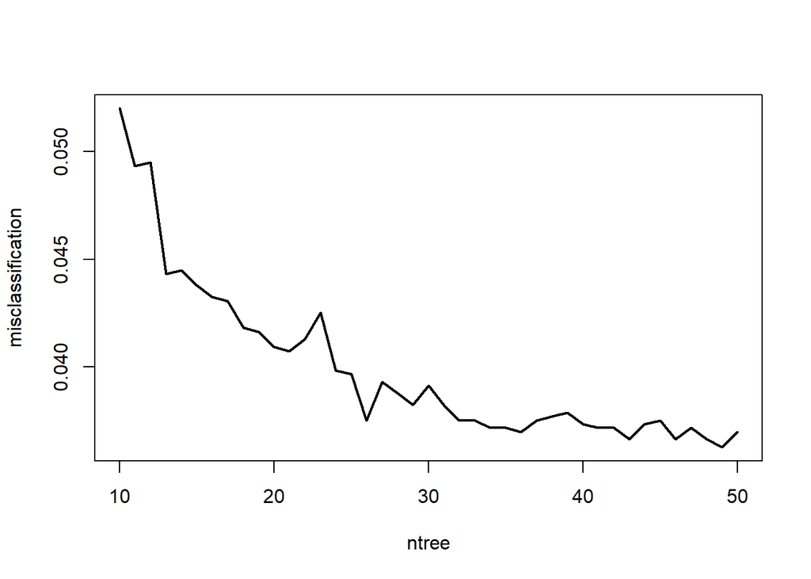

```r
ntree <- seq(10, 50, by = 1)
misclassification <- vector(mode = "numeric", length = length(ntree))
for (i in seq_along(ntree)) {
  set.seed(123)
  model <- bagging(
    potability ~.,
    data = train,
    coob = TRUE,
    nbag = ntree[i])
  misclassification[i] = model$err
}

plot(ntree, misclassification, type="l", lwd="2")
```

2. Model cu optimizarea numarului de bags: Optăm pentru 36 de bags:

```r
mod_bagged_36 <- bagging(potability ~ .,
                     data = train, coob = TRUE, nbag = 36)
mod_bagged_36
```

```
##
## Bagging classification trees with 36 bootstrap replications
##
## Call: bagging.data.frame(formula = potability ~ ., data = train, coob = TRUE,
##     nbag = 36)
##
## Out-of-bag estimate of misclassification error:  0.0332
```

```r
pred_mod_bagged_36 <- predict(mod_bagged_36, newdata = test, target = "class")
(cmb2 <- confusionMatrix(pred_mod_bagged_36, factor(test$potability)))
```

```
## Confusion Matrix and Statistics
##
##           Reference
## Prediction   No  Yes
##        No  2099   55
##        Yes   27  219
##
##                Accuracy : 0.9658
##                  95% CI : (0.9578, 0.9727)
##     No Information Rate : 0.8858
##     P-Value [Acc > NIR] : < 2.2e-16
##
##                   Kappa : 0.8232
##
##  Mcnemar's Test P-Value : 0.002867
##
##             Sensitivity : 0.9873
##             Specificity : 0.7993
##          Pos Pred Value : 0.9745
##          Neg Pred Value : 0.8902
##              Prevalence : 0.8858
##          Detection Rate : 0.8746
##    Detection Prevalence : 0.8975
##       Balanced Accuracy : 0.8933
##
##        'Positive' Class : No
##
```

3. Model Bagging cu caret si Cross-Validation:

```r
mod_bagged_cv <- train(x,
                   y,
                   method="treebag",
                   trControl=train_control,
                   nbag = 36,
                   importance=TRUE)

mod_bagged_cv
```

```
## Bagged CART
##
## 5596 samples
##   20 predictor
##    2 classes: 'No', 'Yes'
##
## No pre-processing
## Resampling: Cross-Validated (10 fold)
## Summary of sample sizes: 5036, 5036, 5036, 5037, 5036, 5036, ...
## Resampling results:
##
##   Accuracy   Kappa
##   0.9639008  0.8053494
```

```r
pred_mod_bagged_cv <- predict(mod_bagged_cv, newdata = test, target = "class")
(cmb3 <- confusionMatrix(pred_mod_bagged_cv, factor(test$potability)))
```

```
## Confusion Matrix and Statistics
##
##           Reference
## Prediction   No  Yes
##        No  2100   59
##        Yes   26  215
##
##                Accuracy : 0.9646
##                  95% CI : (0.9564, 0.9716)
##     No Information Rate : 0.8858
##     P-Value [Acc > NIR] : < 2.2e-16
##
##                   Kappa : 0.8152
##
##  Mcnemar's Test P-Value : 0.0005187
##
##             Sensitivity : 0.9878
##             Specificity : 0.7847
##          Pos Pred Value : 0.9727
##          Neg Pred Value : 0.8921
##              Prevalence : 0.8858
##          Detection Rate : 0.8750
##    Detection Prevalence : 0.8996
##       Balanced Accuracy : 0.8862
##
##        'Positive' Class : No
##
```

```r
model <- c('bagged1','bagged2','bagged_cv')
accuracy <- c(cmb1$overall['Accuracy'], cmb2$overall['Accuracy'], cmb3$overall['Accuracy'])
sensitivity <- c(cmb1$byClass['Sensitivity'], cmb2$byClass['Sensitivity'], cmb3$byClass['Sensitivity'])
specificity <- c(cmb1$byClass['Specificity'], cmb2$byClass['Specificity'], cmb3$byClass['Specificity'])
performance <- data.frame(model, accuracy, sensitivity, specificity)
performance
```

| model | accuracy | sensitivity | specificity |
| --- | --- | --- | --- |
| bagged1 | 0.9608333 | 0.9882408 | 0.7481752 |
| bagged2 | 0.9658333 | 0.9873001 | 0.7992701 |
| bagged_cv | 0.9645833 | 0.9877705 | 0.7846715 |

Vom selecta modelul bagged2 drept cel mai performant:

```r
best_bagged <- mod_bagged_36
```

## Random Forest

1. Model simplu cu biblioteca randomForest:

```r
set.seed(123)
mod_rf1 <- randomForest(
  formula = potability ~ .,
  data = train
) #selecteaza aleatoriu 6 variabile la fiecare impartire
#pt ca avem 20 variabile in total si m=p/3 =11/3 aprox = 3
mod_rf1
```

```
##
## Call:
##  randomForest(formula = potability ~ ., data = train)
##                Type of random forest: classification
##                      Number of trees: 500
## No. of variables tried at each split: 4
##
##         OOB estimate of  error rate: 4.25%
## Confusion matrix:
##       No Yes class.error
## No  4927  31 0.006252521
## Yes  207 431 0.324451411
```

Vizualizarea evolutiei ratei erorii de clasificare:

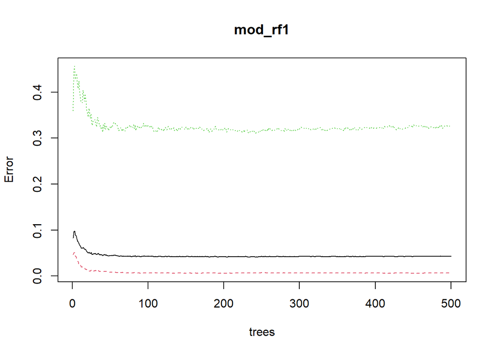

```r
plot(mod_rf1)
```

```r
pred_mod_rf1 <- predict(mod_rf1, test, target ="class")
(cm1 <- confusionMatrix(pred_mod_rf1, factor(test$potability)))
```

```
## Confusion Matrix and Statistics
##
##           Reference
## Prediction   No  Yes
##        No  2105   80
##        Yes   21  194
##
##                Accuracy : 0.9579
##                  95% CI : (0.9491, 0.9656)
##     No Information Rate : 0.8858
##     P-Value [Acc > NIR] : < 2.2e-16
##
##                   Kappa : 0.7704
##
##  Mcnemar's Test P-Value : 7.87e-09
##
##             Sensitivity : 0.9901
##             Specificity : 0.7080
##          Pos Pred Value : 0.9634
##          Neg Pred Value : 0.9023
##              Prevalence : 0.8858
##          Detection Rate : 0.8771
##    Detection Prevalence : 0.9104
##       Balanced Accuracy : 0.8491
##
##        'Positive' Class : No
##
```

Tuning:

```r
set.seed(123)
hyper_grid <- expand.grid(
  mtry = seq(2, 20, by = 1), # nr de atribute dintr-un split;
  node_size = seq(3, 9, by = 2),
  sample_size = c(.55, .632, .7, .8),
  OOB_ERR = 0
)


for (i in 1:nrow(hyper_grid)) {
  model <- ranger(
    formula = potability ~ .,
    data = train,
    num.trees = 500,
    mtry = hyper_grid$mtry[i],
    min.node.size = hyper_grid$node_size[i],
    sample.fraction = hyper_grid$sample_size[i],
    seed = 123
  )
  hyper_grid$OOB_ERR[i] <- model$prediction.error #pastreaza eroarea pentru fiecare combinatie
}

hyper_grid %>%
  arrange(OOB_ERR) %>%
  top_n(-10)
```

| mtry | node_size | sample_size | OOB_ERR |
| --- | --- | --- | --- |
| 19 | 3 | 0.8 | 0.03305933 |
| 16 | 9 | 0.8 | 0.03323803 |
| 16 | 3 | 0.8 | 0.03341673 |
| 17 | 7 | 0.8 | 0.03341673 |
| 16 | 7 | 0.8 | 0.03359543 |
| 20 | 5 | 0.8 | 0.03377412 |
| 12 | 3 | 0.8 | 0.03395282 |
| 14 | 3 | 0.8 | 0.03395282 |
| 15 | 5 | 0.8 | 0.03395282 |
| 16 | 5 | 0.8 | 0.03395282 |

[output cut: 4 more lines]

Identificam parametrii optimi: mtry = 19 atribute, node_size = 3, sample_size = 0.8.

2. Model ajustat prin tuning:

```r
mod_rf_tuned <- randomForest(
  formula = potability ~ .,
  data = train,
  num.trees = 500,
  mtry  = 19,
  min.node.size = 3,
  sample.fraction = .8
)
mod_rf_tuned
```

```
##
## Call:
##  randomForest(formula = potability ~ ., data = train, num.trees = 500,      mtry = 19, min.node.size = 3, sample.fraction = 0.8)
##                Type of random forest: classification
##                      Number of trees: 500
## No. of variables tried at each split: 19
##
##         OOB estimate of  error rate: 3.34%
## Confusion matrix:
##       No Yes class.error
## No  4922  36 0.007260992
## Yes  151 487 0.236677116
```

```r
pred_mod_rf_tuned <- predict(mod_rf_tuned, test, target ="class")
(cm_tuned <- confusionMatrix(pred_mod_rf_tuned, factor(test$potability)))
```

```
## Confusion Matrix and Statistics
##
##           Reference
## Prediction   No  Yes
##        No  2102   58
##        Yes   24  216
##
##                Accuracy : 0.9658
##                  95% CI : (0.9578, 0.9727)
##     No Information Rate : 0.8858
##     P-Value [Acc > NIR] : < 2.2e-16
##
##                   Kappa : 0.8214
##
##  Mcnemar's Test P-Value : 0.0002682
##
##             Sensitivity : 0.9887
##             Specificity : 0.7883
##          Pos Pred Value : 0.9731
##          Neg Pred Value : 0.9000
##              Prevalence : 0.8858
##          Detection Rate : 0.8758
##    Detection Prevalence : 0.9000
##       Balanced Accuracy : 0.8885
##
##        'Positive' Class : No
##
```

3. Model cu caret si Cross-Validation:

```r
mod_rf2 <- train(potability~.,
                data = train,
                method = 'rf',
                trControl = train_control)
mod_rf2
```

```
## Random Forest
##
## 5596 samples
##   20 predictor
##    2 classes: 'No', 'Yes'
##
## No pre-processing
## Resampling: Cross-Validated (10 fold)
## Summary of sample sizes: 5037, 5036, 5036, 5036, 5036, 5036, ...
## Resampling results across tuning parameters:
##
##   mtry  Accuracy   Kappa
##    2    0.9383519  0.6178527
##   11    0.9660468  0.8146156
##   20    0.9658695  0.8159573
##
## Accuracy was used to select the optimal model using the largest value.
## The final value used for the model was mtry = 11.
```

```r
pred_mod_rf2 <- predict(mod_rf2, test, target ="class")
(cm2 <- confusionMatrix(pred_mod_rf2, factor(test$potability)))
```

```
## Confusion Matrix and Statistics
##
##           Reference
## Prediction   No  Yes
##        No  2107   59
##        Yes   19  215
##
##                Accuracy : 0.9675
##                  95% CI : (0.9596, 0.9742)
##     No Information Rate : 0.8858
##     P-Value [Acc > NIR] : < 2.2e-16
##
##                   Kappa : 0.8284
##
##  Mcnemar's Test P-Value : 1.006e-05
##
##             Sensitivity : 0.9911
##             Specificity : 0.7847
##          Pos Pred Value : 0.9728
##          Neg Pred Value : 0.9188
##              Prevalence : 0.8858
##          Detection Rate : 0.8779
##    Detection Prevalence : 0.9025
##       Balanced Accuracy : 0.8879
##
##        'Positive' Class : No
##
```

## Evaluarea performantei modelelor:

```r
pred_rf1_roc <- predict(mod_rf1, test, type="prob")
pred_rf2_roc <- predict(mod_rf2, test, type="prob")
pred_rf_tuned <- predict(mod_rf_tuned, test, type = "prob")
```

Realizam graficul curbelor ROC pentru cele 3 modele RF:

```r
data_frame <- data.frame(actual.class = test$potability, probability = pred_rf1_roc, pred_rf2_roc, pred_rf_tuned)
roc_rf1 <- roc(actual.class~pred_rf1_roc[,1], data_frame)
roc_rf2 <- roc(actual.class~pred_rf2_roc[,1], data_frame)
roc_rf_tuned <- roc(actual.class~pred_rf_tuned[,1], data_frame)
```

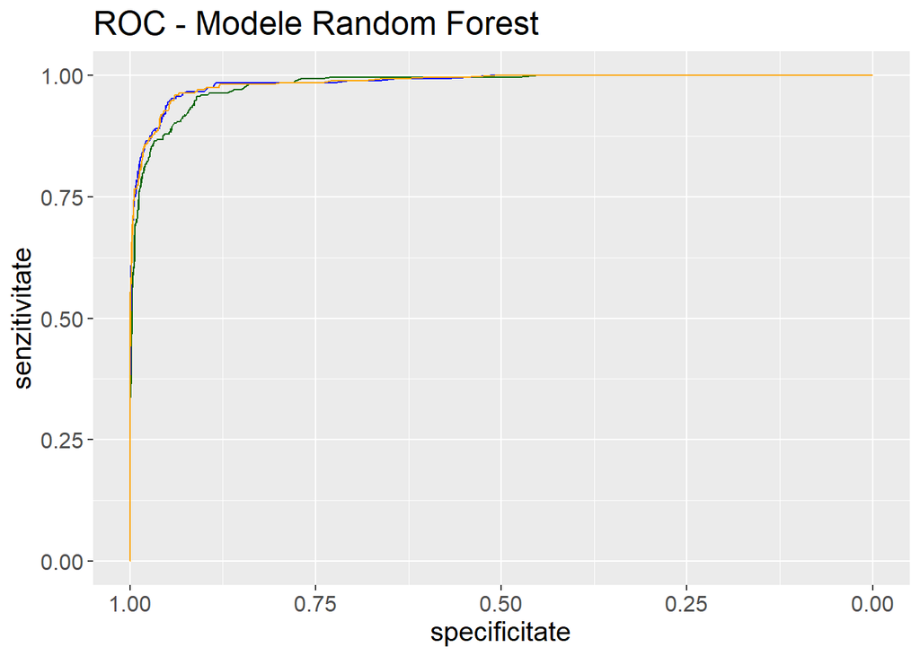

```r
df1 <- data.frame(
  specificity1 <- roc_rf1$specificities,
  sensitivity1 <- roc_rf1$sensitivities)

df2 <- data.frame(
  specificity2 <- roc_rf2$specificities,
  sensitivity2 <- roc_rf2$sensitivities)

df3 <- data.frame(
  specificity3 <- roc_rf_tuned$specificities,
  sensitivity3 <- roc_rf_tuned$sensitivities)

ggplot() +
  geom_line(df1, mapping = aes(x= specificity1, y = sensitivity1), color = "dark green") +
  scale_x_reverse() +
  theme(text = element_text(size = 15))+
geom_line(df2, mapping = aes(x = specificity2, y = sensitivity2), color = "blue") +
  scale_x_reverse() +
  theme(text = element_text(size = 15))+
geom_line(df3, mapping = aes(x = specificity3, y = sensitivity3), color = "orange") +
  scale_x_reverse() +
  theme(text = element_text(size = 15))+
labs(
  title = 'ROC - Modele Random Forest',
  x = 'specificitate',
  y = 'senzitivitate')
```

Analizam performanta celor 3 modele:

```r
model <- c('rf1','rf2','rf_tuned')
auc <- c(auc(roc_rf1), auc(roc_rf2), auc(roc_rf_tuned))
accuracy <- c(cm1$overall['Accuracy'], cm2$overall['Accuracy'], cm_tuned$overall['Accuracy'])
sensitivity <- c(cm1$byClass['Sensitivity'], cm2$byClass['Sensitivity'], cm_tuned$byClass['Sensitivity'])
specificity <- c(cm1$byClass['Specificity'], cm2$byClass['Specificity'], cm_tuned$byClass['Specificity'])
performance <- data.frame(model, accuracy, auc, sensitivity, specificity)
performance
```

| model | accuracy | auc | sensitivity | specificity |
| --- | --- | --- | --- | --- |
| rf1 | 0.9579167 | 0.9812849 | 0.9901223 | 0.7080292 |
| rf2 | 0.9675000 | 0.9856804 | 0.9910630 | 0.7846715 |
| rf_tuned | 0.9658333 | 0.9856272 | 0.9887112 | 0.7883212 |

Vom alege modelul rf_2 drept cel mai bun Random Forest.

```r
best_rf <- mod_rf2
```

### Evaluare Curbe ROC

```r
pred_lr_roc <- predict(best_lr, test, type = "prob")
pred_nb_roc <- predict(best_nb, test, type = "prob")
pred_tree_roc <- predict(best_tree, test, target = "class")
pred_bagged_roc <- predict(best_bagged, test, type = "prob")
pred_rf_roc <- predict(best_rf, test, type = "prob")


df_roc <- data.frame(actual.class = test$potability, probability = pred_lr_roc, pred_nb_roc, pred_tree_roc, pred_bagged_roc, pred_rf_roc)
roc_lr <- roc(actual.class~pred_lr_roc[,1], df_roc)
roc_nb <- roc(actual.class~pred_nb_roc$posterior[,1], df_roc)
roc_tree <- roc(actual.class~pred_tree_roc[,1], df_roc)
roc_bagged <- roc(actual.class~pred_bagged_roc[,1], df_roc)
roc_rf <- roc(actual.class~pred_rf_roc[,1], df_roc)
```

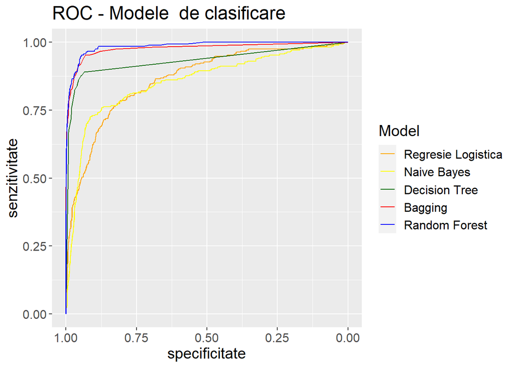

```r
df_lr <- data.frame(
  specificity1 <- roc_lr$specificities,
  sensitivity1 <- roc_lr$sensitivities)

df_nb <- data.frame(
  specificity2 <- roc_nb$specificities,
  sensitivity2 <- roc_nb$sensitivities)

df_tree <- data.frame(
  specificity3 <- roc_tree$specificities,
  sensitivity3 <- roc_tree$sensitivities)

df_bag <- data.frame(
  specificity4 <- roc_bagged$specificities,
  sensitivity4 <- roc_bagged$sensitivities)

df_rf <- data.frame(
  specificity5 <- roc_rf$specificities,
  sensitivity5 <- roc_rf$sensitivities)

colors <- c("Regresie Logistica" = "orange", "Naive Bayes" = "yellow", "Decision Tree" = "dark green", "Bagging" = "red", "Random Forest" = "blue")

ggplot() +
  geom_line(df_lr, mapping = aes(x= specificity1, y = sensitivity1, color = "Regresie Logistica")) +
  scale_x_reverse() +
  theme(text = element_text(size = 15))+
geom_line(df_nb, mapping = aes(x = specificity2, y = sensitivity2, color = "Naive Bayes")) +
  scale_x_reverse() +
  theme(text = element_text(size = 15))+
geom_line(df_tree, mapping = aes(x = specificity3, y = sensitivity3, color = "Decision Tree")) +
  scale_x_reverse() +
  theme(text = element_text(size = 15))+
geom_line(df_bag, mapping = aes(x = specificity4, y = sensitivity4, color = "Bagging")) +
  scale_x_reverse() +
  theme(text = element_text(size = 15))+
geom_line(df_rf, mapping = aes(x = specificity5, y = sensitivity5, color = "Random Forest")) +
  scale_x_reverse() +
  theme(text = element_text(size = 15))+
labs(
  title = 'ROC - Modele  de clasificare',
  x = 'specificitate',
  y = 'senzitivitate',
  color = 'Model')+
  scale_color_manual(values = colors)
```

Matricele de confuzie pentru extragerea masurilor de evaluare a performantei:

```r
pred_lr_roc <- as_tibble(pred_lr_roc) %>% mutate(class = ifelse(No >= Yes, "No", "Yes"))
cm_lr <- confusionMatrix(factor(pred_lr_roc$class), factor(test$potability))

cm_nb <- confusionMatrix(pred_nb_roc$class, factor(test$potability))

pred_tree_roc <- as_tibble(pred_tree_roc) %>% mutate(class = ifelse(No >= Yes, "No", "Yes"))
cm_tree <- confusionMatrix(factor(pred_tree_roc$class), factor(test$potability))

pred_bagged_roc <- as_tibble(pred_bagged_roc) %>% mutate(class = ifelse(No >= Yes, "No", "Yes"))
cm_bag <- confusionMatrix(factor(pred_bagged_roc$class), factor(test$potability))
pred_rf_roc <- as_tibble(pred_rf_roc) %>% mutate(class = ifelse(No >= Yes, "No", "Yes"))
cm_rf <- confusionMatrix(factor(pred_rf_roc$class), factor(test$potability))
```

Tabelul cu parametrii de evaluare aferenti fiecarui model, ordonat dupa acuratețe si AUC:

```r
model <- c('lr','nb','tree','bagging','rf')
auc <- c(auc(roc_lr), auc(roc_nb), auc(roc_tree), auc(roc_bagged), auc(roc_rf))

accuracy <- c(cm_lr$overall['Accuracy'], cm_nb$overall['Accuracy'], cm_tree$overall['Accuracy'], cm_bag$overall['Accuracy'],cm_rf$overall['Accuracy'])

sensitivity <- c(cm_lr$byClass['Sensitivity'], cm_nb$byClass['Sensitivity'], cm_tree$byClass['Sensitivity'], cm_bag$byClass['Sensitivity'],cm_rf$byClass['Sensitivity'])

specificity <- c(cm_lr$byClass['Specificity'], cm_nb$byClass['Specificity'], cm_tree$byClass['Specificity'], cm_bag$byClass['Specificity'], cm_rf$byClass['Specificity'])

p_value <- c(cm_lr$overall['AccuracyPValue'], cm_nb$overall['AccuracyPValue'], cm_tree$overall['AccuracyPValue'], cm_bag$overall['AccuracyPValue'],cm_rf$overall['AccuracyPValue'])

performance <- data.frame(model, accuracy, auc, sensitivity, specificity, p_value)
performance %>% arrange(desc(accuracy), desc(auc))
```

| model | accuracy | auc | sensitivity | specificity | p_value |
| --- | --- | --- | --- | --- | --- |
| rf | 0.9675000 | 0.9856804 | 0.9910630 | 0.7846715 | 2.648127e-48 |
| bagging | 0.9658333 | 0.9771151 | 0.9891816 | 0.7846715 | 5.141989e-46 |
| tree | 0.9545833 | 0.9324749 | 0.9797742 | 0.7591241 | 1.137105e-32 |
| lr | 0.9075000 | 0.8635267 | 0.9783631 | 0.3576642 | 3.425114e-04 |
| nb | 0.9050000 | 0.8555888 | 0.9383819 | 0.6459854 | 1.404128e-03 |

În concluzie, cea mai bună predicție de clasificare se obține prin utilizarea modelului Random Forest. Ordinea performanței este cea din tabelul de mai sus.